# Modelo Multiplicativo

## Le agregamos el MA(1):

```r
fit7
```

```
Call:
arima(x = x, order = c(1, 0, 1), seasonal = c(order = c(1, 1, 0), period = 4),
    method = "ML")

Coefficients:
         ar1     ma1     sar1
      0.7925  0.4280  -0.3763
s.e.  0.0757  0.1232   0.1048

sigma^2 estimated as 0.001016:  log likelihood = 165.15,  aic = -322.31
```

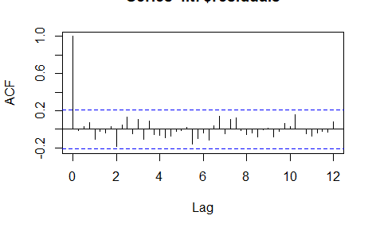

```r
acf(fit7$residuals, lag.max=48)
```

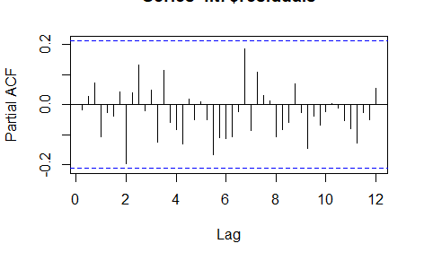

```r
pacf(fit7$residuals, lag.max=48)
```

FAS: Se soluciona potencial SMA.

FAP: Soluciona el AR(1).

Preciera que nada que ver, pero es la interaccion de los distintos polinomios.

```r
fit_auto=auto.arima(x)
fit_auto=auto.arima(x)
fit_auto
```

```
Series: x
ARIMA(1,0,1)(0,1,1)[4]

Coefficients:
         ar1     ma1     sma1
      0.8605  0.3710  -0.5311
s.e.  0.0673  0.1189   0.1127

sigma^2 estimated as 0.0009887:  log likelihood=167.54
AIC=-327.08   AICc=-326.56   BIC=-317.45
```

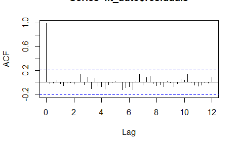

```r
acf(fit_auto$residuals, lag.max=48)
```

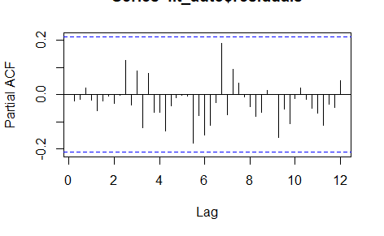

```r
pacf(fit_auto$residuals, lag.max=48)
```

Tambien queda una masa. Muy buenos correlogramas.

```r
AIC(fit1)
```

```
[1] -209.9122
```

```r
AIC(fit2)
```

```
[1] -292.5506
```

```r
AIC(fit3)
```

```
[1] -316.0896
```

```r
AIC(fit3b)
```

```
[1] -318.4995
```

```r
AIC(fit4)
```

```
[1] -209.9122
```

```r
AIC(fit5)
```

```
[1] -301.3262
```

```r
AIC(fit6)
```

```
[1] -313.8245
```

```r
AIC(fit7)
```

```
[1] -322.3077
```

```r
AIC(fit_auto)
```

```
[1] -327.0796
```

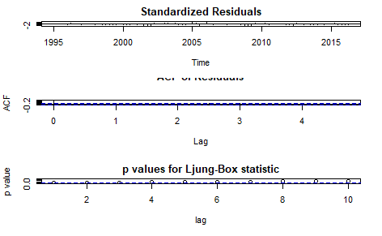

```r
tsdiag(fit3)
```

```
ARCH heteroscedasticity test for residuals
alternative: heteroscedastic

Portmanteau-Q test:
     order   PQ p.value
[1,]     4 14.0  0.0072
[2,]     8 15.0  0.0583
[3,]    12 18.7  0.0965
[4,]    16 30.8  0.0142
[5,]    20 33.7  0.0285
[6,]    24 38.1  0.0339
Lagrange-Multiplier test:
     order     LM  p.value
[1,]     4 18.698 0.000316
[2,]     8  7.704 0.359451
[3,]    12  3.716 0.977502
[4,]    16  1.749 0.999988
[5,]    20  0.936 1.000000
[6,]    24  0.486 1.000000
```

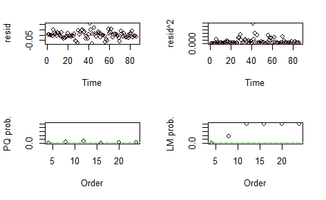

```r
arch.test(fit3, output = TRUE)
```

```r
shapiro.test(fit3$residuals)
```

```
    Shapiro-Wilk normality test

data:  fit3$residuals
W = 0.97923, p-value = 0.1811
```

Hay autocorrleacion —-> lo bochamos de una. * Problemas de heterocedasticidad. Pormantieu lo bocha. Shapiro pasa la normalidad

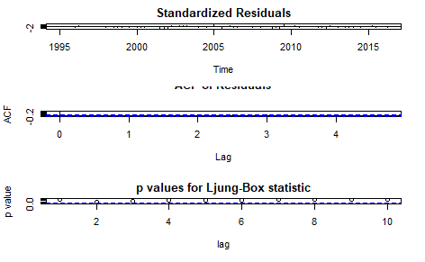

```r
tsdiag(fit3b)
```

```
ARCH heteroscedasticity test for residuals
alternative: heteroscedastic

Portmanteau-Q test:
     order   PQ p.value
[1,]     4 13.8 0.00802
[2,]     8 16.0 0.04178
[3,]    12 18.7 0.09503
[4,]    16 28.0 0.03155
[5,]    20 30.2 0.06603
[6,]    24 34.1 0.08368
Lagrange-Multiplier test:
     order     LM  p.value
[1,]     4 24.113 2.37e-05
[2,]     8  9.340 2.29e-01
[3,]    12  4.313 9.60e-01
[4,]    16  2.181 1.00e+00
[5,]    20  1.230 1.00e+00
[6,]    24  0.684 1.00e+00
```

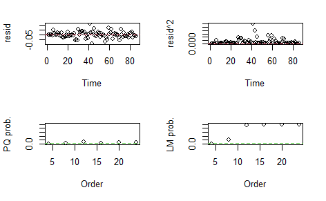

```r
arch.test(fit3b, output = TRUE)
```

```r
shapiro.test(fit3b$residuals)
```

```
    Shapiro-Wilk normality test

data:  fit3b$residuals
W = 0.97482, p-value = 0.09092
```

Bastante bien con la autocorrelacion. Normalidad pasa. Queda con algunos temas de heterocedasticidad.

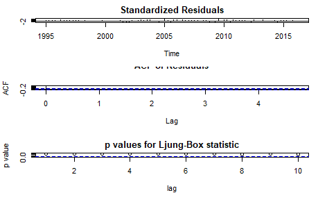

```r
tsdiag(fit7)
```

```
ARCH heteroscedasticity test for residuals
alternative: heteroscedastic

Portmanteau-Q test:
     order    PQ p.value
[1,]     4  3.51   0.477
[2,]     8  4.75   0.784
[3,]    12 10.71   0.554
[4,]    16 13.76   0.617
[5,]    20 16.55   0.682
[6,]    24 20.75   0.654
Lagrange-Multiplier test:
     order     LM  p.value
[1,]     4 26.780 6.55e-06
[2,]     8 11.322 1.25e-01
[3,]    12  5.600 8.99e-01
[4,]    16  2.488 1.00e+00
[5,]    20  1.249 1.00e+00
[6,]    24  0.569 1.00e+00
```

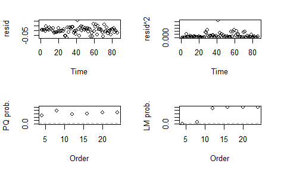

```r
arch.test(fit7, output = TRUE)
```

```r
shapiro.test(fit7$residuals)
```

```
    Shapiro-Wilk normality test

data:  fit7$residuals
W = 0.97897, p-value = 0.1739
```

Autocorrelacion muy bien, todos valores alejados del p critico, muy lejor de la linea.

Mejora bastante heterocedasticidad, Pormateiu da okay, LM maso menos. Hay una observacion en el valor cuarenta y pico que es com un outlier, que trae algunos problemas seguramente.

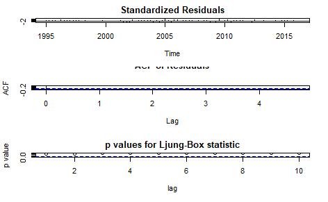

```r
tsdiag(fit_auto)
```

```r
#arch.test(fit_auto, output = TRUE) da error porque necesita otro tipo de objeto
shapiro.test(fit_auto$residuals)
```

```
    Shapiro-Wilk normality test

data:  fit_auto$residuals
W = 0.97539, p-value = 0.09954
```

Muy bien autocorrlelacion. Normalidad la cumple . El arch.test() tira error. Operativo de R, fit auto no usa la funcion arima(), si no que usa ARIMA(), y no arch test no funciona con este objeto. La solucion seria correrlo con los mismos parametros en arima().

Veamos si podemos reproducir la estimación:

```
ARCH heteroscedasticity test for residuals
alternative: heteroscedastic

Portmanteau-Q test:
     order    PQ p.value
[1,]     4  6.72   0.152
[2,]     8  8.67   0.371
[3,]    12 12.64   0.396
[4,]    16 17.20   0.373
[5,]    20 20.17   0.447
[6,]    24 24.34   0.442
Lagrange-Multiplier test:
     order    LM  p.value
[1,]     4 28.85 2.41e-06
[2,]     8 11.12 1.33e-01
[3,]    12  5.77 8.88e-01
[4,]    16  2.77 1.00e+00
[5,]    20  1.28 1.00e+00
[6,]    24  0.66 1.00e+00
```

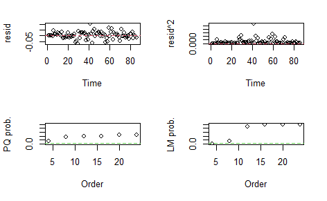

```r
arch.test(fit_auto_manual, output = TRUE)
```

Queda bastante bien en la Pormantieu y LM bocha el primer retardo.

En general quedan mejor fit7 y fit_auto Ambos tienen un pequeño problema de heterocedasticidad, pero son los que mejor andubieron.

```
Forecast for univariate time series:
    Lead Forecast    S.E Lower Upper
87     1     4.50 0.0323  4.44  4.57
88     2     4.49 0.0514  4.39  4.59
89     3     4.45 0.0662  4.32  4.58
90     4     4.59 0.0785  4.43  4.74
91     5     4.50 0.0960  4.31  4.69
92     6     4.49 0.1124  4.27  4.71
93     7     4.45 0.1270  4.20  4.70
94     8     4.58 0.1402  4.31  4.86
95     9     4.50 0.1577  4.19  4.80
96    10     4.48 0.1749  4.14  4.83
97    11     4.45 0.1907  4.07  4.82
98    12     4.58 0.2055  4.18  4.98
99    13     4.49 0.2241  4.05  4.93
100   14     4.48 0.2424  4.00  4.95
101   15     4.44 0.2597  3.93  4.95
------
Note: confidence level = 95 %
```

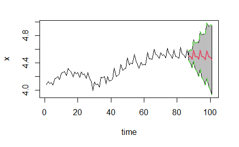

```r
for3b <-  forecast(fit3b, 15)
```

```
Forecast for univariate time series:
    Lead Forecast    S.E Lower Upper
87     1     4.49 0.0319  4.43  4.55
88     2     4.48 0.0503  4.38  4.58
89     3     4.45 0.0590  4.34  4.57
90     4     4.59 0.0638  4.47  4.72
91     5     4.50 0.0749  4.35  4.64
92     6     4.49 0.0848  4.32  4.65
93     7     4.45 0.0904  4.28  4.63
94     8     4.59 0.0938  4.41  4.77
95     9     4.49 0.1036  4.29  4.69
96    10     4.48 0.1131  4.26  4.70
97    11     4.45 0.1187  4.22  4.68
98    12     4.59 0.1221  4.35  4.83
99    13     4.49 0.1302  4.24  4.75
100   14     4.48 0.1380  4.21  4.75
101   15     4.45 0.1426  4.17  4.73
------
Note: confidence level = 95 %
```

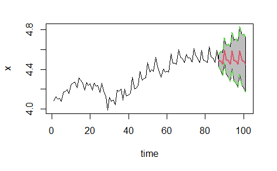

```r
for7 <-  forecast(fit7, 15)
```

Vemos los pronosticos.

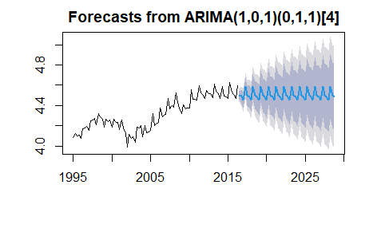

Mirar la amplitud de las bandas son bastante grandes, que son del 95%.

El fit 7 vende unas bandas mas chicas, captura un poco mejor la fluctuacion estacional y supuestamente logra bandas mas chicas, tiene que ver con que estaba mejor en el diagnostico. En comparacion con el fit3.

Y el fit_auto: A 50 no se la juega mucho con la tendencia. De todas formas no sabemos cual es la tendencia de la serie.

Cuando le ponemos 50 no agarra la tendencia, se trata de una tendencia estocastica, no sabemos si se va para arriba ni para abajo. Mejor lance ir por el medio.

Si le agregamos componente deterministico, la tendencia. Te aseguras que la tome si la conoces.